# Lab 3: MAUP in Practice — Tessellations and Point-in-Polygon

National Dam Inventory (NID): From Counts to Local Clustering

Taia Storrs

taia.storrs@colostate.edu

# Background

In this lab we will explore the impacts of tessellated surfaces and the modifiable areal unit problem (MAUP) using the National Dam Inventory maintained by the United States Army Corps of Engineers. The work requires writing reusable functions and careful consideration of feature aggregation/simplification, spatial joins, and data visualization. The end goal is to visualize the distribution of dams and their purposes across the country.

**DISCLAIMER**: This lab can be computationally intensive. For some steps you may be processing hundreds of millions of relations; run code chunk-by-chunk during development rather than knitting the whole document repeatedly. Your final knit may take a few minutes. Be proud — the report will summarize analyses over very large geometric relations.

This lab covers 4 main skills:

1. **Tessellating surfaces** to discretize space
2. **Geometry simplification** to expedite expensive intersections
3. **Writing functions** to automate repetitive reporting and mapping tasks
4. **Point-in-polygon counts** to aggregate point data

## Graduate-Level Expectations

In addition to producing correct code and outputs, your submission should:

- **Justify methodological choices**: Why did you choose a particular tessellation `keep` percentage for simplification? How did you balance computational efficiency with map detail?
- **Document performance impacts**: Measure and report computation time and geometric accuracy changes resulting from simplification. How do results differ?
- **Apply spatial reasoning**: Use spatial predicates (e.g., `st_touches`, `st_contains`) to identify and describe geometric relationships in the dam dataset that raw counts cannot reveal.
- **Compare across methods**: When multiple tessellation approaches yield different clustering patterns, explain which pattern better supports real-world dam management decisions and why.
- **Connect to lecture**: Explicitly cite the MAUP problem, simplification algorithms (Douglas-Peucker vs. Visvalingam), and spatial predicate definitions from week 3 lectures in your analysis.

### Libraries

```r
install.packages("rmapshaper")
install.packages("kableExtra")
install.packages("janitor")
```

```r
install.packages("remotes")
remotes::install_github("mikejohnson51/AOI")
```

# Question 1:

Here we will prepare five tessellated surfaces from CONUS and write a function to plot them in a descriptive way.

### Step 1.1

First, we need a spatial file of CONUS counties. For future area calculations we want these in an equal area projection (`EPSG:5070`).

To achieve this:

- get an `sf` object of US counties (`AOI::aoi_get(state = "conus", county = "all")`)
- transform the data to `EPSG:5070`

```r
counties <- AOI::aoi_get(state = "conus", county = "all") %>%
  st_transform(crs = 5070)
```

### Step 1.2

For triangle based tessellations we need point locations to serve as our “anchors”.

To achieve this:

- generate county centroids using `st_centroid`
- Since, we can only tessellate over a feature we need to *combine* or *union* the resulting 3,108 `POINT` features into a single `MULTIPOINT` feature
- Since these are point objects, the difference between union/combine is mute

```r
centroids <- st_centroid(counties) %>%
  st_union()
class(centroids)
```

```
[1] "sfc_MULTIPOINT" "sfc"
```

### Step 1.3

Tessellations/Coverage’s describe the **extent** of a region with geometric shapes, called **tiles**, with *no* overlaps or gaps.

**Tiles** can range in *size*, *shape*, *area* and have different methods for being created.

Some methods generate triangular tiles across a set of defined points (e.g. `Voronoi` and Delaunay triangulation)

Others generate equal area tiles over a known extent (`st_make_grid`)

For this lab, we will create surfaces of CONUS using using 4 methods, 2 based on an extent and 2 based on point anchors:

**Tessellations** :

- `st_voronoi`: creates a Voronoi tessellation
- `st_triangulate`: triangulates a set of points (not constrained)

**Coverages**:

- `st_make_grid`: creates a square grid covering the geometry of an sf or sfc object
- `st_make_grid(square = FALSE)`: creates a hexagonal grid covering the geometry of an sf or sfc object
- The side of coverage tiles can be defined by a cell resolution or a specified number of cell in the X and Y direction

For this step:

- Make a voroni tessellation over your county centroids (`MULTIPOINT`)
- Make a triangulated tessellation over your county centroids (`MULTIPOINT`)
- Make a gridded coverage with n = 70, over your counties object
- Make a hexagonal coverage with n = 70, over your counties object

In addition to creating these 4 coverage’s we need to add an ID to each *tile*.

To do this:

- add a new column to each tessellation that spans from `1:n()`.
- Remember that **ALL** tessellation methods return an `sfc` `GEOMETRYCOLLECTION`, and to add attribute information - like our ID - you will have to coerce the `sfc` list into an `sf` object (`st_sf` or `st_as_sf`)

Last, we want to ensure that our surfaces are topologically valid/simple.

- To ensure this, we can pass our surfaces through `st_cast`.
- Remember that casting an object explicitly (e.g. `st_cast(x, "POINT")`) changes a geometry
- If no output type is specified (e.g. `st_cast(x)`) then the cast attempts to simplify the geometry.
- If you don’t do this you might get unexpected “TopologyException” errors.

```r
# Voronoi
voronoi <- st_voronoi(centroids) %>%
  st_cast() %>%
  st_as_sf() %>%
  st_set_geometry("geometry") %>%
  mutate(id = 1:n())

# Delaunay triangulation
triangulate <- st_triangulate(centroids) %>%
  st_cast() %>%
  st_as_sf() %>%
  mutate(id = 1:n())

# Square grid
square <- st_make_grid(counties, n = 70) %>%
  st_as_sf() %>%
  mutate(id = 1:n())

# Hexagonal grid
hex <- st_make_grid(counties, n = 70, square = FALSE) %>%
  st_as_sf() %>%
  mutate(id = 1:n())
```

```r
# Checks
nrow(voronoi)
```

```
[1] 3108
```

```r
nrow(triangulate)
```

```
[1] 6198
```

```r
nrow(square)
```

```
[1] 4900
```

```r
nrow(hex)
```

```
[1] 3718
```

### Step 1.4

If you plot the above tessellations you’ll see that the **Voronoi**, **Delaunay triangulation**, **hexagon**, and **square grids** all produce regions far beyond the boundaries of CONUS.

We need to cut these boundaries to CONUS borders.

To do this, we need two different approaches: - **`st_intersection()`** for Voronoi and Delaunay (these tessellations create geometries that extend infinitely/far beyond the study area; intersection clips them at the exact boundary) - **`st_filter()`** for hexagon and square grids (these regular grids are already designed to fit; filtering keeps only the tiles that intersect CONUS)

Either way, we’ll need a geometry of CONUS to serve as our clipping feature. We can get this by unioning our existing county boundaries.

```r
conus_boundary <- st_union(counties)
```

### Step 1.5

With a single feature boundary, we must carefully consider the complexity of the geometry. Remember, the more points our geometry contains, the more computations needed for spatial predicates our differencing. For a task like ours, we do not need a finely resolved coastal boarder.

To achieve this:

- Simplify your unioned border using the Visvalingam algorithm provided by `rmapshaper::ms_simplify`.
- Choose what percentage of vertices to retain using the `keep` argument and work to find the highest number that provides a shape *you* are comfortable with for the analysis:

## Validation Checkpoint (Optional)

After simplification, verify the boundary is still valid and covers all dams:

```r
# Check: Is the simplified boundary valid?
st_is_valid(conus_simple)

# Check: Does it still contain all of CONUS?
st_bbox(conus_simple)  # Should cover roughly [-125, 24] to [-66, 49]

# Check: Visual comparison
plot(conus_boundary, main = "Original")
plot(conus_simple, main = "Simplified")
```

## Simplification: Boundary Only, Not Tessellation

**Important distinction**: This step simplifies the **CONUS boundary container** we use for clipping the tessellated surfaces. Simplification affects *only* the geometry of the clipping operation — it speeds up the intersection computation by reducing boundary vertices. Your tessellation tiles themselves remain **high-resolution** and unchanged. You are not simplifying the tessellation itself, only the container we clip with.

- Once you are happy with your simplification, use the `mapview::npts` function to report the number of points in your original object, and the number of points in your simplified object.
- How many points were you able to remove? What are the consequences of doing this computationally?

```r
# original point count
mapview::npts(conus_boundary)
```

```
[1] 11292
```

```r
# Simplify
conus_simple <- ms_simplify(conus_boundary, keep = 0.05)

# simplified point count
mapview::npts(conus_simple)
```

```
[1] 577
```

I retained 5% of vertices (577 of 11,292 points), reducing the boundary complexity by 95%. Since this simplified geometry is only used as a clipping container and not displayed directly, the loss of coastal and border detail has no impact on analytical accuracy. The simplification substantially reduces computation time during st_intersection() operations.

- Finally, crop **all four grids** to the CONUS boundary—but using different methods:
  - **Voronoi & Delaunay** (geometry-based tessellations): Use `st_intersection()` to *cut* these geometries at the CONUS boundary. These tessellations create boundaries that extend well beyond CONUS; intersection actually trims them.
  - **Hexagon & Square grids** (regular grids): Use `st_filter()` to keep only tiles that touch CONUS. These grids are already regularly aligned; filtering just discards edge tiles without modifying them.

```r
# Voronoi and Delaunay — st_intersection()
voronoi_clipped     <- st_intersection(voronoi, conus_simple)
triangulate_clipped <- st_intersection(triangulate, conus_simple)

# Square and hex — st_filter()
square_clipped <- st_filter(square, conus_simple)
hex_clipped    <- st_filter(hex, conus_simple)
```

```r
# checks
nrow(voronoi_clipped)
```

```
[1] 3108
```

```r
nrow(triangulate_clipped)
```

```
[1] 6198
```

```r
nrow(square_clipped)
```

```
[1] 3130
```

```r
nrow(hex_clipped)
```

```
[1] 2308
```

## Why Different Cropping Methods?

**The distinction matters for your spatial analysis:**

- **`st_intersection()` on Voronoi/Delaunay**: Produces edges/boundaries that align precisely with the CONUS border. Tiles at the edge are cut, not discarded. This is geometrically accurate but creates irregular edge shapes.
- **`st_filter()` on hexagon/square grids**: Keeps only complete regular tiles that touch CONUS, discarding edge tiles. The boundary is a stair-step pattern following the regular grid.

### Step 1.6

The last step is to plot your tessellations. We don’t want to write out 5 ggplots (or mindlessly copy and paste)

Instead, lets make a function that takes an `sf` object as *arg1* and a character string as *arg2* and returns a ggplot object showing *arg1* titled with *arg2*.

The form of a function is:

```r
name = function(arg1, arg2) {

#  ... code goes here ...

}
```

For this function:

- The name can be anything you chose, *arg1* should take an `sf` object, and *arg2* should take a character string that will title the plot
- In your function, the code should follow our standard `ggplot` practice where your data is *arg1*, and your title is *arg2*
- The function should also enforce the following:
  - a `white` fill
  - a `navy` border
  - a `size` of 0.2
  - `theme_void``
  - a caption that reports the number of features in *arg1*
    - You will need to paste character stings and variables together.

```r
plot_tessellation = function(tess_sf, title_text) {
  ggplot(data = tess_sf) +
    geom_sf(fill = "white", color = "navy", size = 0.2) +
    theme_void() +
    labs(
      title = title_text,
      caption = paste("Number of features:", nrow(tess_sf))
    )
}
```

### Step 1.7

Use your new function to plot each of your tessellated surfaces and the original county data (5 plots in total):

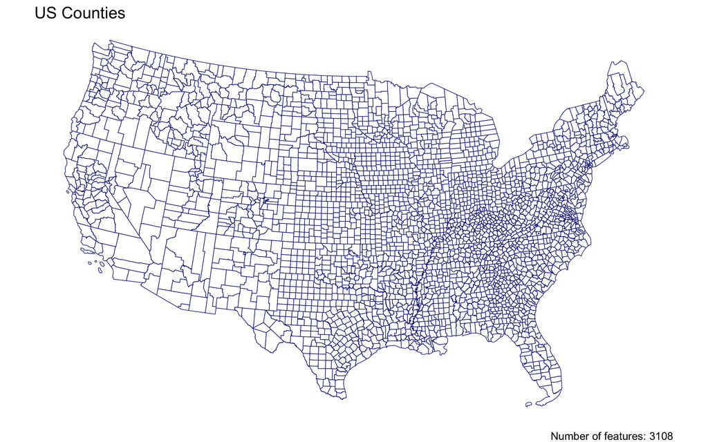

```r
plot_tessellation(counties,             "US Counties")
```

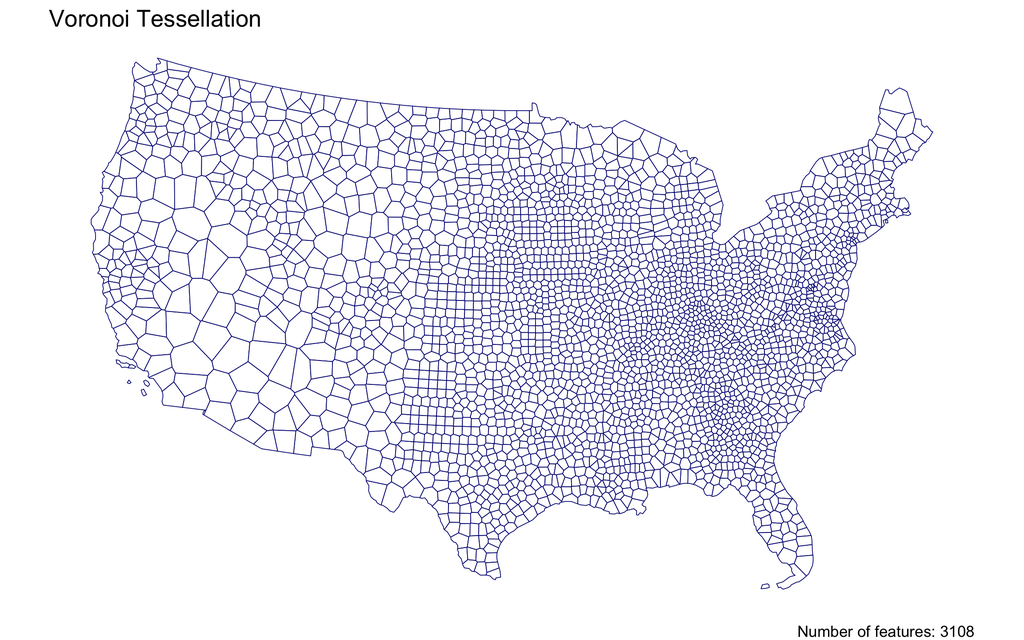

```r
plot_tessellation(voronoi_clipped,      "Voronoi Tessellation")
```

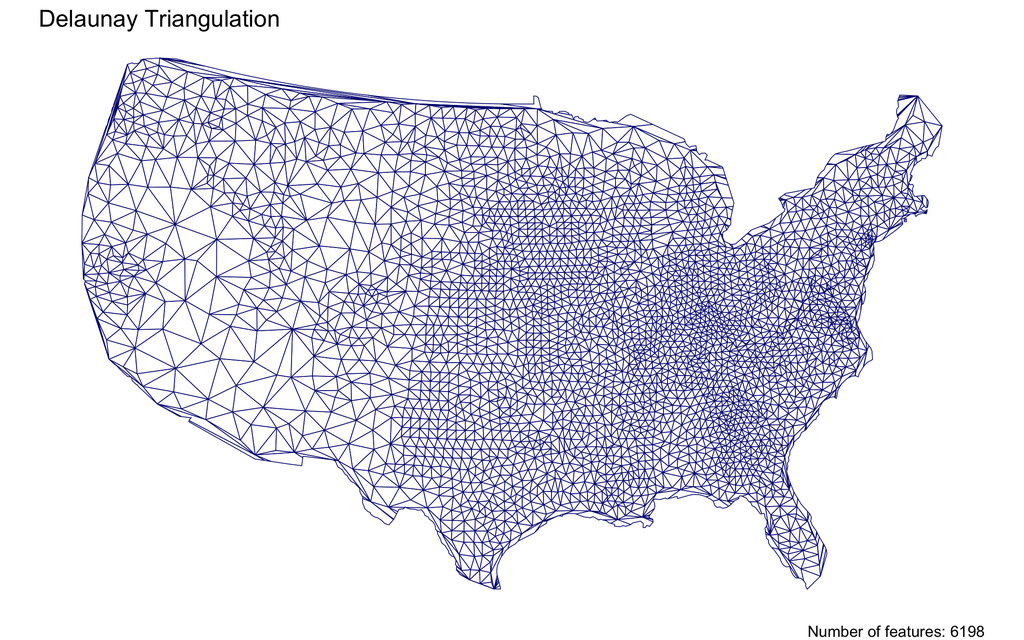

```r
plot_tessellation(triangulate_clipped,  "Delaunay Triangulation")
```

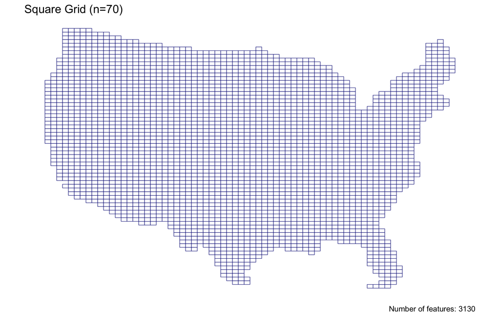

```r
plot_tessellation(square_clipped,       "Square Grid (n=70)")
```

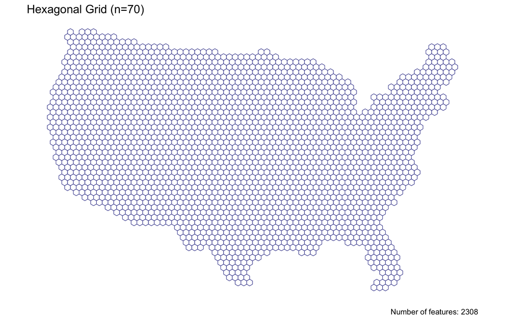

```r
plot_tessellation(hex_clipped,          "Hexagonal Grid (n=70)")
```

# Question 2:

In this question, we will write out a function to summarize our tessellated surfaces.

### Step 2.1

First, we need a function that takes a `sf` object and a `character` string and returns a `data.frame`.

For this function:

- The function name can be anything you chose, *arg1* should take an `sf` object, and *arg2* should take a character string describing the object
- In your function, calculate the area of `arg1`; convert the units to km<sup>2</sup>; and then drop the units
- Next, create a `data.frame` containing the following:
  1. text from *arg2*
  2. the number of features in *arg1*
  3. the mean area of the features in *arg1* (km<sup>2</sup>)
  4. the standard deviation of the features in *arg1*
  5. the total area (km<sup>2</sup>) of *arg1*
- Return this `data.frame`

```r
sum_tess = function(tess_sf, description) {


  area <- st_area(tess_sf) %>%
    set_units(km^2) %>%
    drop_units()

  data.frame(
    description = description,
    n_features  = nrow(tess_sf),
    mean_area   = mean(area),
    sd_area     = sd(area),
    total_area  = sum(area)
  )
}
```

### Step 2.2

Use your new function to summarize each of your tessellations and the original counties.

### Step 2.3

Multiple `data.frame` objects can bound row-wise with `bind_rows` into a single `data.frame`

For example, if your function is called `sum_tess`, the following would bind your summaries of the triangulation and voroni object.

```r
bind_rows(
  sum_tess(triangulate_grid, "triangulation"),
  sum_tess(voronoi_grid, "voronoi")
)
```

```r
summary_table <- bind_rows(
  sum_tess(counties,             "Counties"),
  sum_tess(voronoi_clipped,      "Voronoi"),
  sum_tess(triangulate_clipped,  "Triangulation"),
  sum_tess(square_clipped,       "Square Grid"),
  sum_tess(hex_clipped,          "Hexagonal Grid")
)
```

### Step 2.4

Once your 5 summaries are bound (2 tessellations, 2 coverage’s, and the raw counties) print the `data.frame` as a nice table using `knitr`/`kableExtra`/`flextable` or your preferred table formatting package.

Tessellation Summary Statistics

| description | n_features | mean_area | sd_area | total_area |
| --- | --- | --- | --- | --- |
| Counties | 3,108 | 2,605.05 | 3,443.71 | 8,096,496 |
| Voronoi | 3,108 | 2,604.43 | 2,917.82 | 8,094,557 |
| Triangulation | 6,198 | 1,290.37 | 1,598.40 | 7,997,700 |
| Square Grid | 3,130 | 2,761.29 | 0.00 | 8,642,833 |
| Hexagonal Grid | 2,308 | 3,781.18 | 0.00 | 8,726,961 |

### Step 2.5

Comment on the traits of each tessellation. Be specific about how these traits might impact the results of a point-in-polygon analysis in the contexts of the modifiable areal unit problem and with respect computational requirements.

Tessellations with high standard deviation in tile area (counties: 3,443 km², Voronoi: 2,917 km²) introduce MAUP bias into point-in-polygon analysis because larger tiles will naturally accumulate more dams regardless of true density. Square and hexagonal grids eliminate this source of bias entirely with sd = 0, making them more appropriate for comparing dam density across space. However, regular grids are computationally simpler and faster to work with since their uniform geometry requires less processing during spatial joins. The triangulation produces the most tiles (6,198) at the smallest mean size (1,290 km²), which gives the finest spatial resolution but at greater computational cost.

# Question 3: Dam Distribution Analysis & Tessellation Selection

The data we will analyze in this lab are from the U.S. Army Corps of Engineers National Dam Inventory (NID). This dataset documents ~91,000 dams in the United States and includes attributes such as design specifications, risk level, age, and purpose.

Dam management agencies face a critical question: **Where are dams actually clustered, and how do I visualize that clustering in a way that supports infrastructure planning decisions?** The answer depends on your choice of geographic boundaries—that is, your tessellation. Different tessellations will reveal different patterns of dam concentration. Your job in this question is to:

1. Quantify dam distributions across multiple tessellation methods
2. Understand how the **modifiable areal unit problem (MAUP)** creates different narratives from the same underlying data
3. **Select and justify the tessellation that best supports management decisions** about dam clustering

For the remainder of this lab we will analyze the distributions of these dams using point-in-polygon analysis.

### Step 3.1

In the tradition of this class - and true to data science/GIS work - you need to find, download, and manage raw data. THe NID dataset is available as a CSV download from the USACE website [here](https://nid.sec.usace.army.mil/nid/#/downloads). Grab the CSV.

- Return to your RStudio Project and read the data in using the `readr::read_csv`
  - Use `janitor::clean_names()` to standardize column names to snake_case (tidy data convention)
  - After reading the data in, be sure to remove rows that don’t have location values (`!is.na()`)
  - Convert the `data.frame` to a `sf` object by defining the coordinates and CRS
  - Transform the data to a CONUS AEA (EPSG:5070) projection - matching your tessellation
  - Filter to include only those within your CONUS boundary

## Data Cleaning with janitor

The NID CSV has messy column names (all caps with spaces). The `janitor::clean_names()` function converts them to clean snake_case (`LONGITUDE` → `longitude`, `DAM NAME` → `dam_name`). This is a lightweight utility that saves time and prevents typos in downstream code. It’s part of data wrangling best practice.

```r
# Prefer a local NID CSV named `nation.csv`; otherwise download to that filename
nid_url <- "https://nid.sec.usace.army.mil/api/nation/csv"
dir.create("data", showWarnings = FALSE)
nid_dest <- "data/nation.csv"
if (file.exists(nid_dest)) {
  message("Using local NID file: ", nid_dest)
} else {
  tryCatch({
    message("Downloading NID CSV to: ", nid_dest)
    download.file(nid_url, nid_dest, quiet = FALSE, mode = "wb")
  }, error = function(e) {
    message("NID download failed: ", e$message)
  })
}

# read the CSV (will error if download failed and file missing)
if (!file.exists(nid_dest)) stop("NID CSV not found at ", nid_dest)
dams <- readr::read_csv(nid_dest, skip =1, show_col_types = FALSE) |>
  janitor::clean_names()

usa <- AOI::aoi_get(state = "conus") %>%
  st_union() %>%
  st_transform(5070)

dams2 <- dams %>%
  filter(!is.na(latitude)) %>%
  st_as_sf(coords = c("longitude", "latitude"), crs = 4326) %>%
  st_transform(5070) %>%
  st_filter(usa)
```

```r
# checks
nrow(dams2)
```

```
[1] 92189
```

```r
st_crs(dams2)$epsg
```

```
[1] 5070
```

### Step 3.2

Following the in-class examples develop an efficient point-in-polygon function that takes:

- points as `arg1`,
- polygons as `arg2`,
- The name of the id column as `arg3`

The function should make use of spatial and non-spatial joins, sf coercion and `dplyr::count`. The returned object should be input `sf` object with a column - `n` - counting the number of points in each tile.

## Point-in-Polygon Function Design Notes

1. **CRS Matching**: Ensure `points` and `polygons` are in the same CRS before calling `st_join()`. If they differ, use `st_transform()` to align them first.
2. **Empty Polygons**: `st_join(...) %>% count(id)` creates one row per intersection found. Polygons with *zero* intersections will appear in the result with `n = 0` **only if** you use a *left join* (default for `st_join()`). If a polygon has no points, make sure your result still includes it; if not, use `st_join(...) %>% right_join(...)` or initialize counts explicitly.
3. **Sparse vs. Dense Matrices**: In this step you’re not creating matrices. However, in Q6.1 you’ll use `st_touches(..., sparse = FALSE)` to build neighbor matrices explicitly. Here in Q3, `st_join()` handles the spatial predicate internally (`st_intersects` by default), so you won’t set sparsity—just know that `st_join()` scales well to large datasets. For troubleshooting performance: if your function runs slowly with 91,000 dams, check whether your tessellation polygons are topologically simple (use `st_is_valid()`).

```r
counties <- counties %>%
  mutate(id = 1:n())
```

```r
point_in_polygon = function(points, polygons, id_col) {
  st_join(polygons, points) %>%
    st_drop_geometry() %>%
    count(.data[[id_col]]) %>%
    setNames(c(id_col, "n")) %>%
    left_join(polygons, by = id_col) %>%
    st_as_sf()
}
```

### Step 3.3

Apply your point-in-polygon function to each of your five tessellated surfaces where:

- Your points are the dams
- Your polygons are the respective tessellation
- The id column is the name of the id columns you defined.

```r
counties_dams     <- point_in_polygon(dams2, counties,             "id")
voronoi_dams      <- point_in_polygon(dams2, voronoi_clipped,      "id")
triangulate_dams  <- point_in_polygon(dams2, triangulate_clipped,  "id")
square_dams       <- point_in_polygon(dams2, square_clipped,       "id")
hex_dams          <- point_in_polygon(dams2, hex_clipped,          "id")
```

### Step 3.4

Lets continue the trend of automating our repetitive tasks through function creation. This time make a new function that extends your previous plotting function.

For this function:

- The name can be anything you chose, *arg1* should take an `sf` object, and *arg2* should take a character string that will title the plot
- The function should also enforce the following:
  - the fill aesthetic is driven by the count column `n`
  - the col is `NA`
  - the fill is scaled to a continuous `viridis` color ramp
  - `theme_void`
  - a caption that reports the number of dams in *arg1* (e.g. `sum(n)`)
    - You will need to paste character stings and variables together.

```r
plot_dam_counts = function(tess_sf, title_text) {
  ggplot(data = tess_sf) +
    geom_sf(aes(fill = n), color = NA) +
    scale_fill_viridis_c() +
    theme_void() +
    labs(
      title = title_text,
      caption = paste("Total dams:", sum(tess_sf$n, na.rm = TRUE))
    )
}
```

### Step 3.5

Apply your plotting function to each of the 5 tessellated surfaces with Point-in-Polygon counts:

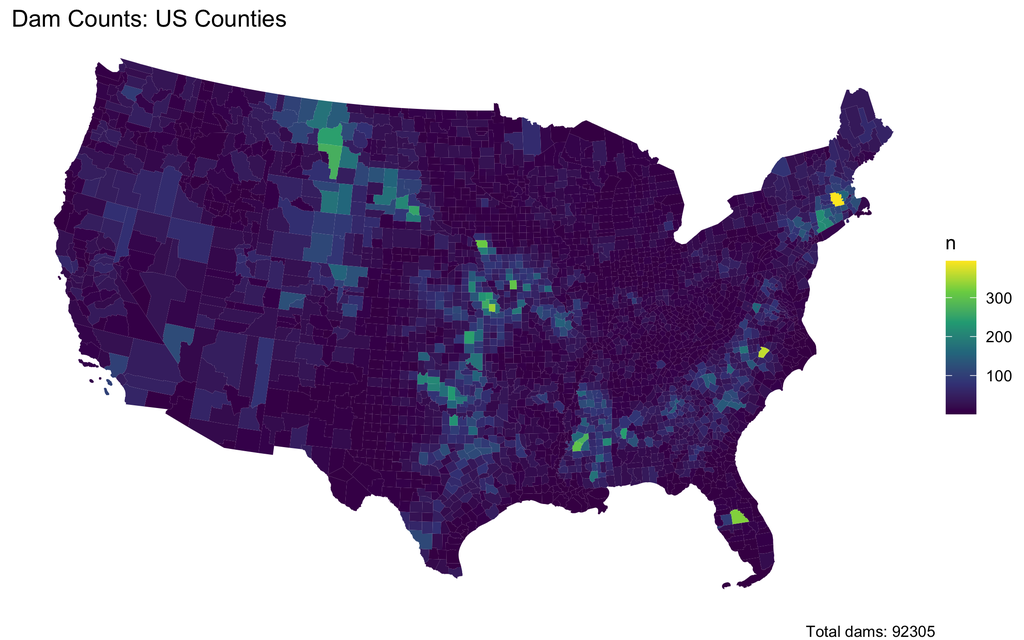

```r
plot_dam_counts(counties_dams,    "Dam Counts: US Counties")
```

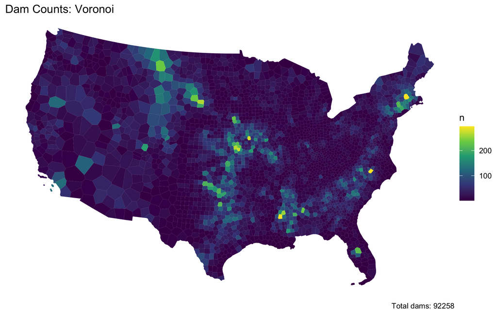

```r
plot_dam_counts(voronoi_dams,     "Dam Counts: Voronoi")
```

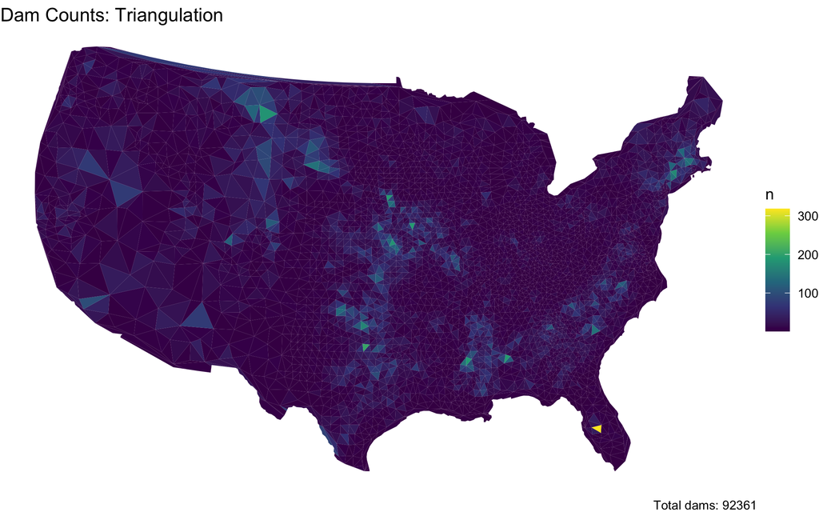

```r
plot_dam_counts(triangulate_dams, "Dam Counts: Triangulation")
```

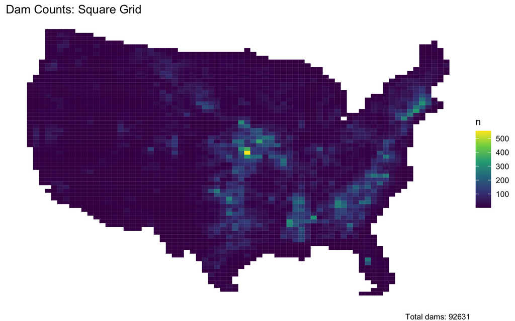

```r
plot_dam_counts(square_dams,      "Dam Counts: Square Grid")
```

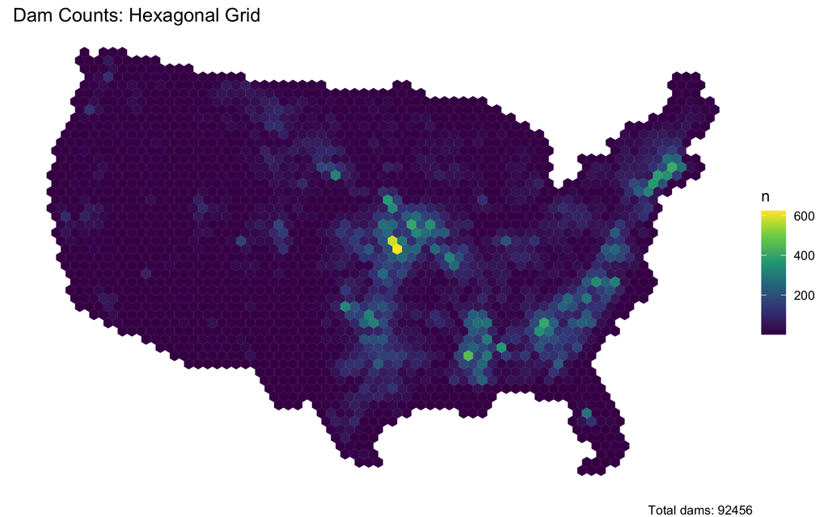

```r
plot_dam_counts(hex_dams,         "Dam Counts: Hexagonal Grid")
```

### Step 3.6

**Policy Analysis: Tessellation and Decision-Making**

Now that you have dam counts across all five tessellation methods, compare the results. Specifically:

**a.** Create a side-by-side visualization (faceted or small multiples) showing dam clustering under each of the five tessellations. Use `patchwork` or `cowplot` to arrange the 5 plots you created in Step 3.5 for direct visual comparison.

**b.** Identify **2–3 geographic regions** where tessellation choice produces substantially *different* patterns (e.g., one method shows a clear hotspot while another shows diffuse distribution). For each region, describe the pattern difference and explain *why* the tessellation geometry creates divergent results. Reference the characteristics from your Q2 summary (number of tiles, mean area, standard deviation).

**c.** **Which single tessellation would you recommend to a dam operations manager seeking to understand geographic clustering?** Justify your choice by addressing: - Does the tessellation align with natural or management decision-making units (e.g., river basins, states, hydrologic regions)? - Does it reveal meaningful patterns without over-fragmenting the landscape or creating artificial boundaries? - How does MAUP influence your recommendation—are other tessellations equally valid, just for different questions? - How did simplification affect your choice? Would a coarser or finer simplification (different `keep` percentage) change your recommendation? - What does “best supports management decisions” mean concretely in your context—does it matter more that hot spots are obvious, or that boundaries align with jurisdictions?

Your answer should be **3–4 paragraphs** and grounded in the actual visualizations and patterns you observe from your tessellation comparisons.

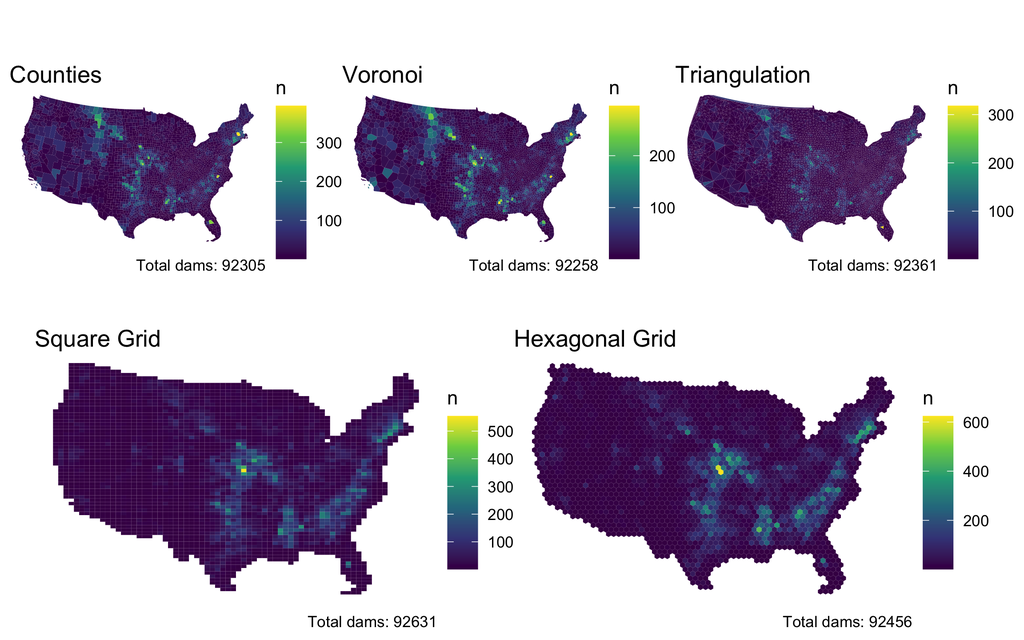

```r
library(patchwork)

p1 <- plot_dam_counts(counties_dams,    "Counties")
p2 <- plot_dam_counts(voronoi_dams,     "Voronoi")
p3 <- plot_dam_counts(triangulate_dams, "Triangulation")
p4 <- plot_dam_counts(square_dams,      "Square Grid")
p5 <- plot_dam_counts(hex_dams,         "Hexagonal Grid")

(p1 + p2 + p3) / (p4 + p5)
```

Looking at the five tessellation maps side-by-side, the overall pattern of dam locations across the United States is fairly consistent, but the way the clusters appear changes depending on how the space is divided. Across all methods, there are clear concentrations of dams in the central United States, especially around Missouri, Arkansas, and Oklahoma, as well as across parts of the Southeast and Appalachian region. However, the intensity and shape of these clusters vary depending on the tessellation. Some methods show very strong hotspots while others spread the dams across more units. This is a good example of the Modifiable Areal Unit Problem, where the patterns we observe depend on the spatial boundaries used in the analysis.

One region where the differences stand out is the Missouri–Arkansas–Oklahoma area. In the square and hexagonal grid maps, this area appears as a very strong hotspot with a few cells containing a large number of dams. Because these grid cells are uniform in size, they group many nearby dams into the same cell, making the cluster look more intense. In the county map, the same dams are distributed across several counties of different sizes, which makes the hotspot look more spread out and less concentrated. The Voronoi and triangulation tessellations fall somewhere in between because they create irregular polygons based on the spacing of points, which captures clustering but without the strong artificial concentration that grids can create.

Another place where tessellation changes the pattern is in the Southeastern/Appalachian region, including Tennessee, Georgia, Alabama, and the Carolinas. In the square grid, this region shows a band of higher dam counts across several adjacent cells. On the county map, that pattern looks more fragmented because counties vary a lot in size and shape. The hexagonal grid highlights the clustering a little more clearly because the cells are evenly sized and have more balanced neighboring relationships. In contrast, the triangulation tessellation breaks the area into many small irregular shapes, which can make the cluster look less obvious. These differences mostly come from the number of tiles and how consistent their sizes are—grids have uniform cell areas while counties and triangulated polygons vary more.

If I had to recommend one tessellation for a dam operations manager trying to understand geographic clustering, I would probably choose the hexagonal grid. Hexagons use equal-area cells and reduce some of the directional bias that square grids can create, which helps highlight spatial patterns more clearly without over-fragmenting the map. That said, counties could still be useful if the goal is to connect the analysis directly to management jurisdictions or policy decisions. Because of MAUP, no single tessellation is universally “correct”—different ones can be useful depending on the question being asked. The level of simplification also matters. Using a much coarser or finer keep percentage could smooth out or reveal additional patterns. In this case, the most helpful tessellation for management decisions is one that makes major dam clusters easy to identify, which could help prioritize monitoring, inspections, or regional water management planning.

# Question 4

The NID provides a comprehensive data dictionary [here](https://files.hawaii.gov/dbedt/op/gis/data/nid_dams_data_dictionary.htm#Purposes). In it we find that dam purposes are designated by a character [code](https://files.hawaii.gov/dbedt/op/gis/data/nid_dams_data_dictionary.htm#Purposes).

These are shown below for convenience (built using knitr on a data.frame called `nid_classifier`):

NID 2019: Dam Purposes

| abbr | purpose |
| --- | --- |
| I | Irrigation |
| H | Hydroelectric |
| C | Flood Control |
| N | Navigation |
| S | Water Supply |
| R | Recreation |
| P | Fire Protection |
| F | Fish and Wildlife |
| D | Debris Control |
| T | Tailings |
| G | Grade Stabilization |
| O | Other |

- In the data dictionary, we see a dam can have *multiple* purposes.
- In these cases, the purpose codes are concatenated in order of decreasing importance. For example, `SCR` would indicate the primary purposes are *Water Supply*, then *Flood Control*, then *Recreation.*
- A standard summary indicates there are over 400 unique combinations of dam purposes:

```r
unique(dams2$purposes) %>% length()
```

```
[1] 574
```

- By storing dam codes as a concatenated string, there is no easy way to identify how many dams serve any one purpose… for example where are the hydro electric dams?

To overcome this data structure limitation, we can identify how many dams serve each purpose by splitting the PURPOSES values (`strsplit`) and tabulating the unlisted results as a data.frame. Effectively this is double/triple/quadruple counting dams bases on how many purposes they serve:

### Step 4.1

- Your task is to create point-in-polygon counts for at *least* 4 of the above dam purposes:
- You will use `grepl` to filter the complete dataset to those with your chosen purpose
- Remember that `grepl` returns a boolean if a given pattern is matched in a string
- `grepl` is vectorized so can be used in `dplyr::filter`

For example:

```r
# Find flood control dams in the first 5 records:
dams2$purposes[1:5]
```

```
[1] "Recreation"   "Recreation"   "Other"
[4] "Other"        "Water Supply"
```

```r
grepl("F", dams2$purposes[1:5])
```

```
[1] FALSE FALSE FALSE FALSE FALSE
```

For your analysis, choose *at least* four of the above codes, and describe why you chose them. Then for each of them, create a subset of dams that serve that purpose using `dplyr::filter` and `grepl`

Finally, use your `point-in-polygon` function to count each subset across your **cropped tessellation from Q1.4** (e.g., `hexagon_clipped` or `square_clipped`).

```r
irrigation_dams <- dams2 %>%
  filter(grepl("I", purposes))

hydroelectric_dams <- dams2 %>%
  filter(grepl("H", purposes))

flood_dams <- dams2 %>%
  filter(grepl("C", purposes))

recreation_dams <- dams2 %>%
  filter(grepl("R", purposes))
```

```r
irrigation_pip   <- point_in_polygon(irrigation_dams,   hex_clipped, "id")
hydroelectric_pip <- point_in_polygon(hydroelectric_dams, hex_clipped, "id")
flood_pip        <- point_in_polygon(flood_dams,        hex_clipped, "id")
recreation_pip   <- point_in_polygon(recreation_dams,   hex_clipped, "id")
```

For this analysis, I selected four dam purposes from the NID classification system: irrigation (I), hydroelectric (H), flood control (C), and recreation (R). I chose these purposes because they represent a mix of infrastructure, resource management, and social uses of dams. Irrigation and hydroelectric dams are closely tied to water supply and energy production, which are major drivers of dam construction in the western and mountainous parts of the United States. Flood control dams are important for reducing flood risk in large river systems, especially in areas with high runoff variability. Recreation dams were included to represent a different type of dam use that is often associated with reservoirs used for boating, fishing, and tourism.

Because the purposes field stores codes as concatenated strings, a single dam can serve multiple purposes and the dataset does not directly provide counts for each purpose individually. To address this, I used grepl() within dplyr::filter() to identify dams that contain each specific purpose code in the string. Since grepl() searches for a pattern anywhere in the text, it allows us to capture dams even if the purpose appears as a secondary or tertiary function. For example, a dam coded as “SCR” would still be counted when searching for flood control (“C”) or recreation (“R”). This approach effectively counts dams for each purpose they serve, even if a single dam appears in multiple categories.

After filtering the dataset into subsets for each purpose, I applied the point-in-polygon counting function used earlier in the assignment to summarize how many dams fall within each polygon of the cropped tessellation from Question 1.4. This allows us to compare how different types of dams are spatially distributed across the United States. By applying the same tessellation to each subset, we can directly compare geographic clustering patterns for irrigation, hydroelectric, flood control, and recreation dams. These results help illustrate how dam purposes vary spatially depending on regional water management needs, landscape characteristics, and infrastructure development.

### Step 4.2

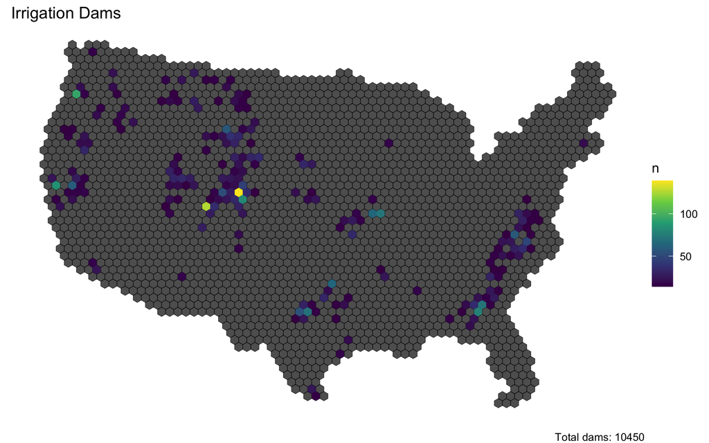

```r
# Irrigation
plot_dam_counts(irrigation_pip, "Irrigation Dams") +
  gghighlight(n > mean(n, na.rm = TRUE) + sd(n, na.rm = TRUE))
```

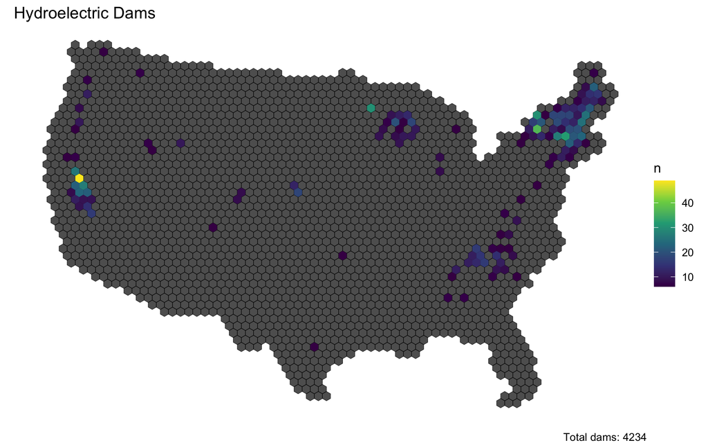

```r
# Hydroelectric
plot_dam_counts(hydroelectric_pip, "Hydroelectric Dams") +
  gghighlight(n > mean(n, na.rm = TRUE) + sd(n, na.rm = TRUE))
```

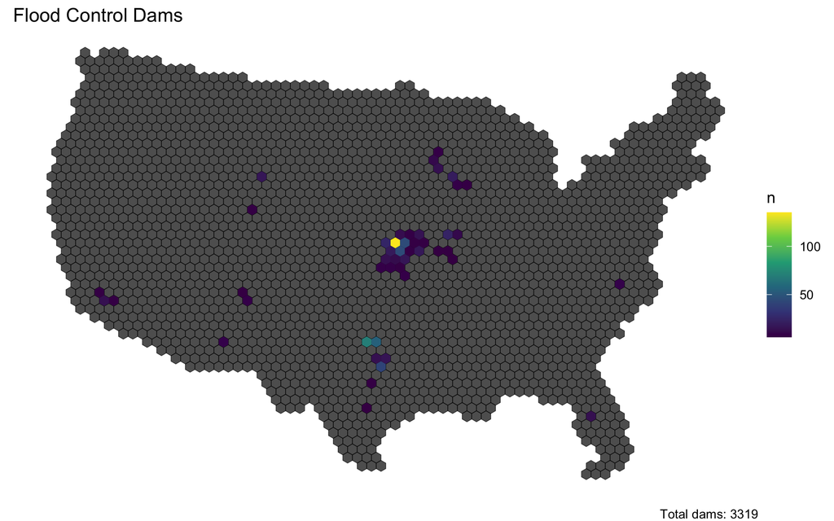

```r
# Flood Control
plot_dam_counts(flood_pip, "Flood Control Dams") +
  gghighlight(n > mean(n, na.rm = TRUE) + sd(n, na.rm = TRUE))
```

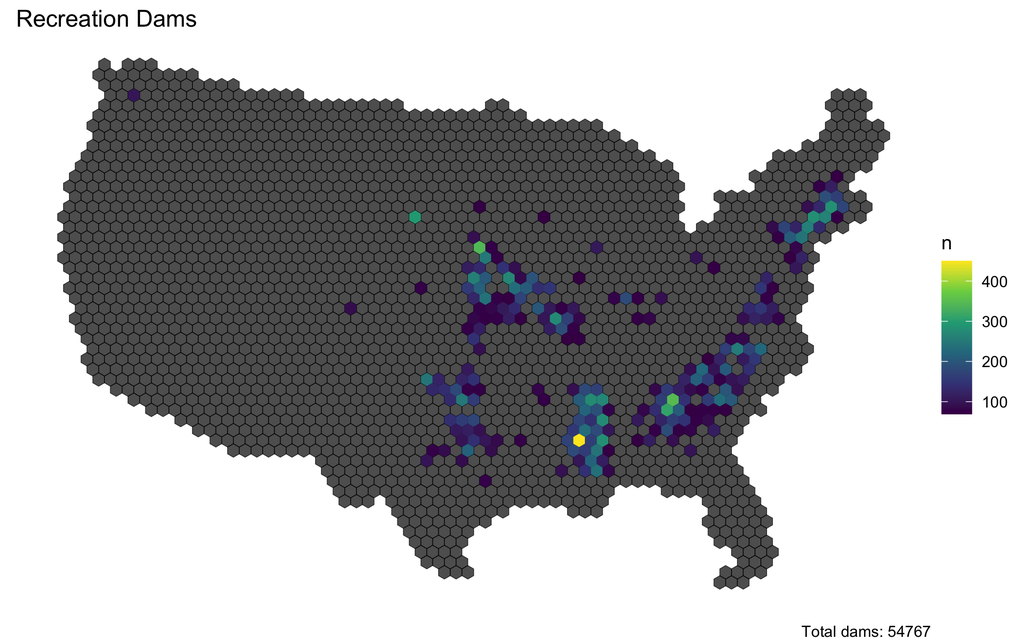

```r
# Recreation
plot_dam_counts(recreation_pip, "Recreation Dams") +
  gghighlight(n > mean(n, na.rm = TRUE) + sd(n, na.rm = TRUE))
```

### Step 4.3

Comment on the geographic distribution of dams you found. Does it make sense? How might the tessellation you chose impact your findings? How does the distribution of dams coincide with other geographic factors such as river systems, climate, ect?

After mapping the point-in-polygon counts for each dam purpose and applying gghighlight, the maps highlight only the tiles where the number of dams is unusually high (greater than the mean plus one standard deviation). This makes it much easier to identify the strongest geographic clusters for each dam purpose instead of visually interpreting the entire distribution. Overall, the patterns largely match what would be expected based on regional climate, topography, and major river systems. Irrigation dams show strong clusters in the western United States, particularly in states like Colorado, Idaho, and California, where water storage is critical for agriculture in more arid climates. Hydroelectric dams appear most concentrated in the Pacific Northwest and parts of the Northeast, which makes sense because these regions have steep terrain and consistent water flow that are well suited for hydropower generation. Flood control dams show clear hotspots in the central United States, especially around the Mississippi and Missouri River systems where large rivers and seasonal flooding require active water management. Recreation dams are much more widely distributed, especially across the Midwest and eastern United States, likely reflecting higher population density and greater demand for reservoirs used for boating, fishing, and other activities.

If counties had been used instead of the hexagonal grid, the patterns would likely appear somewhat different. Counties vary widely in size across the United States, with very large counties in the western states and smaller ones in the east. Because of this, using counties could make some clusters appear weaker or more spread out simply due to the size of the administrative boundaries. In contrast, the hexagonal grid uses uniform spatial units, which allows the analysis to highlight areas with high concentrations of dams more consistently. This reduces the bias that can occur when spatial units vary greatly in area.

Overall, the hexagonal tessellation helps make regional patterns easier to see because each tile has the same size and shape, which improves visual comparability across the map. Hexagons also have more balanced neighboring relationships than squares, which helps represent spatial patterns without introducing directional bias. While hexagons do not correspond to administrative or watershed boundaries, they are useful for exploratory spatial analysis because they highlight clusters without being influenced by political boundaries. In this case, the hexagonal grid helps reveal the major regional hotspots for different dam purposes while keeping the patterns relatively easy to interpret.

**Optional: Connect to Q6** — For purposes you chose in Q4, hypothesize in 1–2 sentences: *“Will [irrigation/hydroelectric] dams show the same LISA hotspots as all dams in Q6, or different patterns? Why?”* After completing Q6, revisit this hypothesis.

# Question 5: Spatial Correlation of Dam Attributes — Introduction to Spatial Regression

Dam characteristics—such as **age, surface area, storage capacity, and purpose**—vary geographically. Understanding the spatial structure of these relationships is foundational to spatial regression modeling (upcoming topics). In this question, you’ll examine whether dam attributes exhibit **spatial dependence** and assess whether neighboring tiles have correlated characteristics.

## Spatial Regression Motivation (Week 3-1 Foundation)

Standard regression assumes observations are **independent**. But spatial data often violates this: dams in the Pacific Northwest likely share design and management practices, leading to **spatially correlated residuals**. This spatial dependence can bias confidence intervals and inflate significance tests in standard OLS regression.

The solution involves **spatial lag models** (Spatial Autoregressive, SAR) or **spatial error models** (SEM) that explicitly model dependence via neighbor relationships. This lab asks: *Do your tessellation neighborhoods reveal spatial structure in dam attributes?*

**For this question, use your cropped tessellation from Q1.4** (your recommended tessellation from Q3, clipped to the CONUS boundary). You’ll examine whether dam attributes (age, size, count) are spatially autocorrelated—evidence that neighboring tiles have similar values, violating independence assumptions.

### Step 5.1

**Aggregate Dam Attributes by Tile**

Using your **cropped tessellation from Q1.4** (your recommended grid from Q3, clipped to CONUS boundary), compute **mean and variance** of key dam attributes within each tile. The NID dataset typically includes:

- **Age**: `year_completed` or similar (compute mean age per tile)
- **Size**: `surface_area_acres` or `normal_pool_elevation` (compute mean per tile)
- **Purpose codes**: `purposes` field (compute dominant purpose per tile; count of dams by purpose)

Aggregate as follows:

```r
# Suggested workflow (write your own implementation):
# 1) spatial join dams to your cropped tessellation
# 2) group by tile id and summarize n_dams, mean_year_completed, mean_surface_area
# 3) join summaries back to geometry and preserve zero-dam tiles
# 4) inspect distributions before mapping
```

**Produce visualizations** showing spatial patterns:

- Map 1: Mean dam age by tile (use viridis scale)
- Map 2: Mean surface area by tile
- Map 3: Dam count by tile (you already have this from Q3)

Do you see geographic clustering of old vs. new dams? Large vs. small dams?

```r
hex_attributes <- st_join(hex_clipped, dams2) %>%
  group_by(id) %>%
  summarise(
    n_dams            = n(),
    mean_year         = mean(year_completed, na.rm = TRUE),
    mean_surface_area = mean(surface_area_acres, na.rm = TRUE)
  ) %>%
  ungroup()
```

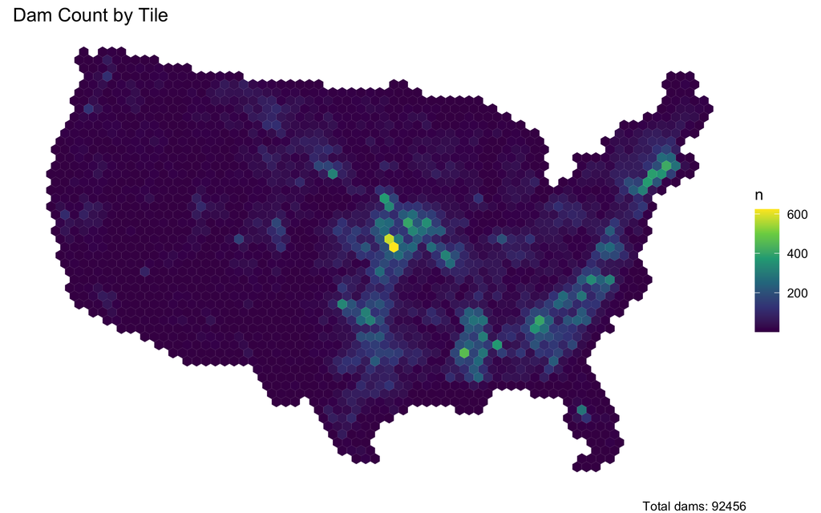

```r
# Map 1 Dam count per tile
plot_dam_counts(hex_dams, "Dam Count by Tile")
```

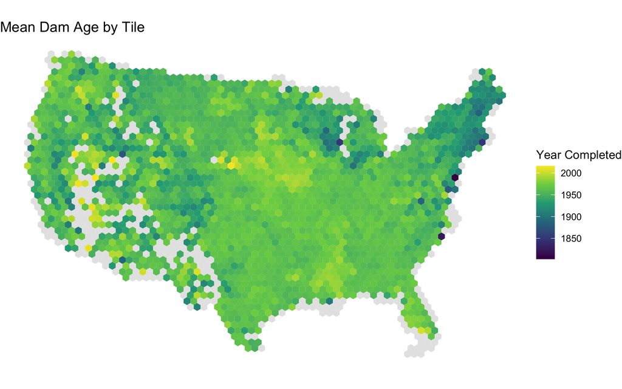

```r
# Map 2 Mean year completed
ggplot(hex_attributes) +
  geom_sf(aes(fill = mean_year), color = NA) +
  scale_fill_viridis_c(na.value = "grey90") +
  theme_void() +
  labs(title = "Mean Dam Age by Tile",
       fill = "Year Completed")
```

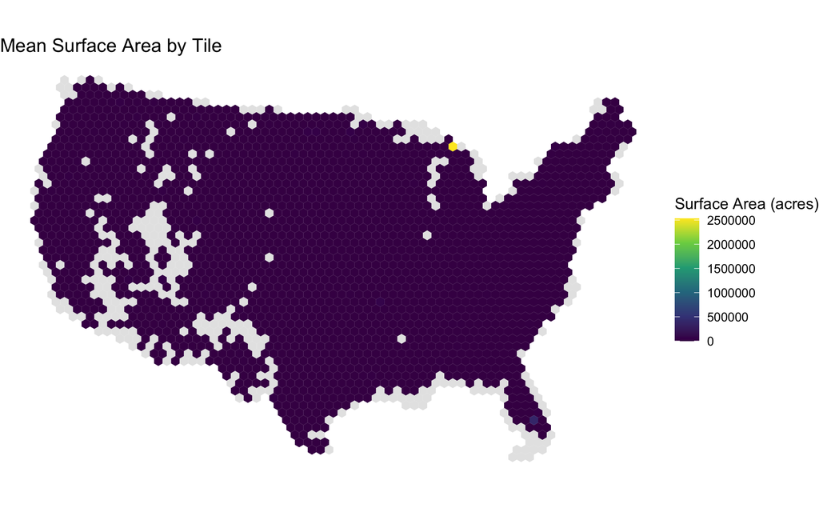

```r
# Map 3 Mean surface area
ggplot(hex_attributes) +
  geom_sf(aes(fill = mean_surface_area), color = NA) +
  scale_fill_viridis_c(na.value = "grey90") +
  theme_void() +
  labs(title = "Mean Surface Area by Tile",
       fill = "Surface Area (acres)")
```

### Step 5.2

**Neighbor Correlation: Local Spatial Variation**

For your tessellation’s neighbor matrix, compute the **spatial lag** of dam attributes: the average value of an attribute in a tile’s neighbors. This reveals whether *spatial neighbors have similar dam attributes*—a key signal that observations are **not independent** (violating OLS assumptions).

## Critical: NA Handling in Spatial Lag Calculations

Many tiles may have **zero dams** (NAs for attributes like mean_year_completed, mean_surface_area). When you compute the spatial lag via matrix multiplication, these NAs propagate and can cause `cor()` to fail with “no complete element pairs.”

**Solution: Impute before spatial lag calculation**

1. Replace NAs in the attribute with the **global mean** (mean across all tiles, ignoring NAs)
2. Compute the spatial lag on the imputed data
3. When correlating, use **only tiles that had original data** (not imputed)

This preserves statistical integrity: neighbors’ contributions are computed correctly, but you only correlate where real observations exist.

```r
# Suggested workflow (write your own implementation):
# 1) build vectors for count, age, and size attributes by tile
# 2) handle NAs explicitly before matrix multiplication
# 3) compute spatial lag as W_std %*% attribute
# 4) correlate each attribute with its lag
# 5) report values and classify as weak/moderate/strong with your own thresholds
```

**Summarize in a table**:

```r
# Create a compact summary table with:
# - attribute name
# - correlation with spatial lag
# - qualitative strength label
# Then add a 1-2 sentence interpretation below the table.
```

```r
# Function 1 build and row-standardize neighbor matrix
standardize_weights <- function(geometry_sf) {
  if (any(!st_is_valid(geometry_sf))) {
    geometry_sf <- st_make_valid(geometry_sf)
  }

  W <- st_touches(geometry_sf, sparse = FALSE)
  diag(W) <- 0

  W_std <- W / rowSums(W)
  W_std[rowSums(W) == 0, ] <- 0

  return(W_std)
}

# Function 2 compute spatial lag with NA imputation
compute_spatial_lag <- function(attribute_vector, weight_matrix,
                                original_na_mask = NULL) {
  if (is.null(original_na_mask)) {
    original_na_mask <- is.na(attribute_vector)
  }

  global_mean <- mean(attribute_vector, na.rm = TRUE)
  attribute_imputed <- ifelse(is.na(attribute_vector),
                              global_mean,
                              attribute_vector)

  spatial_lag <- weight_matrix %*% attribute_imputed
  spatial_lag <- as.vector(spatial_lag)

  return(list(
    lag     = spatial_lag,
    imputed = attribute_imputed,
    na_mask = original_na_mask
  ))
}
```

```r
# build standardized weight matrix
W_std <- standardize_weights(hex_clipped)

# Compute spatial lag for each attribute
lag_n    <- compute_spatial_lag(hex_dams$n,                    W_std)
lag_year <- compute_spatial_lag(hex_attributes$mean_year,      W_std)
lag_area <- compute_spatial_lag(hex_attributes$mean_surface_area, W_std)

# Compute correlations
cor_n    <- cor(lag_n$imputed,    lag_n$lag,    use = "complete.obs")
cor_year <- cor(lag_year$imputed[!lag_year$na_mask],
                lag_year$lag[!lag_year$na_mask],    use = "complete.obs")
cor_area <- cor(lag_area$imputed[!lag_area$na_mask],
                lag_area$lag[!lag_area$na_mask],    use = "complete.obs")
```

```r
correlation_table <- data.frame(
  Attribute   = c("Dam Count", "Mean Year Completed", "Mean Surface Area"),
  Correlation = round(c(cor_n, cor_year, cor_area), 3),
  Strength    = case_when(
    c(cor_n, cor_year, cor_area) > 0.6 ~ "Strong",
    c(cor_n, cor_year, cor_area) > 0.3 ~ "Moderate",
    TRUE ~ "Weak"
  )
)

knitr::kable(correlation_table,
             caption = "Spatial Lag Correlations") %>%
  kableExtra::kable_styling("striped", full_width = TRUE)
```

Spatial Lag Correlations

| Attribute | Correlation | Strength |
| --- | --- | --- |
| Dam Count | 0.839 | Strong |
| Mean Year Completed | 0.637 | Strong |
| Mean Surface Area | 0.001 | Weak |

The spatial lag analysis helps show whether neighboring tiles tend to have similar dam characteristics. By correlating each attribute with the average value of that attribute in neighboring tiles, we can see how much spatial dependence exists in the data. The results show very different levels of spatial correlation across the three attributes. Dam count has the strongest relationship with its spatial lag (r ≈ 0.839), indicating strong spatial clustering. This means that tiles with many dams are very likely to be surrounded by other tiles with many dams as well. This pattern makes sense because dams tend to follow river networks and watershed infrastructure, which extend across space rather than appearing randomly in isolated locations.

The mean year completed attribute also shows a strong positive spatial correlation (r ≈ 0.637). This suggests that neighboring tiles tend to contain dams built during similar time periods. In practice, this reflects the regional history of dam construction in the United States. Large dam-building programs often occurred at regional scales, such as federal infrastructure projects during the mid-20th century. Because many dams within the same watershed or region were constructed during similar development periods, the average completion year tends to be similar across neighboring tiles.

In contrast, mean surface area shows almost no spatial correlation with its neighbors (r ≈ 0.001). This indicates that the size of reservoirs within one tile does not predict the size of reservoirs in nearby tiles. Reservoir size is largely determined by local geography, engineering design, and specific project goals, rather than broader regional trends. For example, a single large reservoir may dominate one tile while surrounding tiles contain only small impoundments or none at all.

Overall, these results highlight how spatial dependence varies by attribute. Dam counts and construction timing both show clear spatial clustering, meaning nearby locations tend to share similar values. Reservoir surface area, however, appears much more locally determined and does not follow a consistent regional pattern. This also suggests that any statistical modeling using these attributes would need to account for spatial autocorrelation, particularly for dam counts and completion year, since neighboring observations are not independent.

### Step 5.3

**Global Question:** Do neighboring tiles resemble each other overall, or is the pattern weak?

Create a single **Moran’s I scatterplot** for one dam attribute from Step 5.2 (for example, mean year completed or dam count). Use standardized values on both axes: the attribute on the x-axis and the spatial lag on the y-axis. The plot should show whether points concentrate along the diagonal or remain widely dispersed.

Your interpretation should focus on the **overall pattern**, not on specific regions. In particular, explain whether the correlation from Step 5.2 suggests strong, moderate, or weak spatial dependence and whether the scatterplot supports that conclusion.

Do **not** create a geographic map here. Save local hotspot mapping for Q6.

## Standardization Details

**Why standardize?** Centering and scaling puts the attribute and spatial lag on the same scale (mean=0, SD=1), making it easy to identify quadrants and interpret outliers.

```r
scale(x, center=TRUE, scale=TRUE)[, 1]
```

Returns a numeric vector (not a matrix). Use `[, 1]` to extract it, or use `as.vector()` explicitly.

```r
# Suggested workflow (write your own implementation):
# 1) standardize the selected attribute and its spatial lag
# 2) assign HH / LL / HL / LH quadrants by sign of (z, lag_z)
# 3) produce a Moran scatterplot with dashed axes at 0
# 4) report quadrant counts and interpret what dominates
```

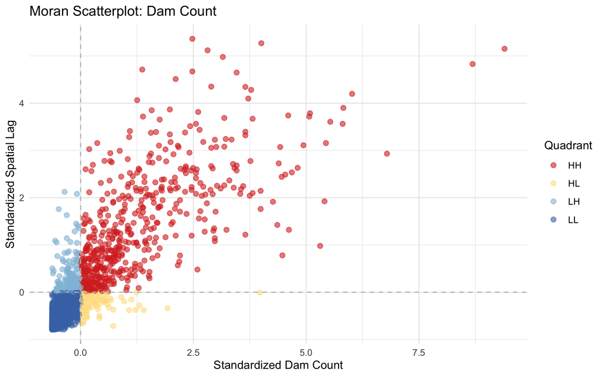

```r
# Adding the LISA quadrant helper function
assign_lisa_quadrants <- function(attribute_vector, spatial_lag_vector) {
  z_attr <- as.vector(scale(attribute_vector))
  z_lag  <- as.vector(scale(spatial_lag_vector))

  quadrant <- case_when(
    z_attr > 0 & z_lag > 0 ~ "HH",
    z_attr < 0 & z_lag < 0 ~ "LL",
    z_attr > 0 & z_lag < 0 ~ "HL",
    z_attr < 0 & z_lag > 0 ~ "LH",
    TRUE ~ NA_character_
  )

  return(list(z_attr = z_attr, z_lag = z_lag, quadrant = quadrant))
}

# Compute quadrants for dam count
lisa_n <- assign_lisa_quadrants(lag_n$imputed, lag_n$lag)

#  scatterplot data frame
moran_data <- data.frame(
  z     = lisa_n$z_attr,
  lag_z = lisa_n$z_lag,
  quad  = lisa_n$quadrant
)

# Plot
ggplot(moran_data, aes(x = z, y = lag_z, color = quad)) +
  geom_point(size = 2, alpha = 0.6) +
  geom_hline(yintercept = 0, linetype = "dashed", color = "gray") +
  geom_vline(xintercept = 0, linetype = "dashed", color = "gray") +
  scale_color_manual(values = c("HH" = "#d73027", "LL" = "#4575b4",
                                "HL" = "#fee090", "LH" = "#91bfdb"),
                     na.value = "gray80") +
  labs(title = "Moran Scatterplot: Dam Count",
       x = "Standardized Dam Count",
       y = "Standardized Spatial Lag",
       color = "Quadrant") +
  theme_minimal()
```

### Step 5.4

**Global Interpretation of Spatial Patterns**

## Writing Guide: Interpreting Spatial Correlation

Use this structure to organize your response:

1. **State your findings clearly** — cite specific correlation values from your Step 5.2 table. Which attributes show the strongest clustering?
2. **Connect to structure** — what does the scatterplot suggest about broad spatial organization, without moving into local mapping yet?
3. **Explain why** — relate to dam history, geology, hydrology, or policy at the regional scale
4. **Analyze patterns** — describe what the Moran scatterplot and correlation values reveal about overall dam distributions

Write 2–3 paragraphs (400–600 words) addressing:

**a. Spatial Clustering Patterns (Quantitative + Geographic)**

Which attributes show the strongest spatial lag correlations (from your Step 5.2 table)? Are correlations > 0.5 (strong) or 0.2–0.5 (moderate)?

- **Dam *count***: Often strongly correlated because high dam density naturally creates neighbors with many dams.
- **Dam *age***: Likely shows clustering if dams were built in regionally-coherent eras (e.g., 1930s TVA construction, 1960s–70s Western expansion).
- **Dam *size***: May be clustered if geology/hydrology favors larger dams in specific regions.

For each attribute, describe whether the clustering seems broad or weak. Does the correlation make geographic sense? Why should dam characteristics be similar in neighboring areas?

**b. Moran Scatterplot Interpretation (Visualization)**

From your Moran scatterplot, describe the spatial distribution of points:

- Do points cluster near the diagonal, suggesting positive spatial autocorrelation?
- Are there many outliers away from the diagonal, suggesting weaker dependence or heterogeneous neighborhoods?
- Does the pattern appear stronger for some attributes than others?

**c. Spatial Structure Implications**

What do these correlation values and Moran scatterplot patterns tell us about dam infrastructure spatial organization? Given your findings, write a brief conclusion synthesizing: - Are neighboring tiles genuinely similar in dam characteristics, or is the clustering weak? - What management or hydrologic factors drive these patterns? - How do findings from your Moran analysis here compare to what you observed in Q4 (dam purposes geography)?

**Note**: In future weeks, we’ll explore how spatial structure revealed here relates to statistical modeling of dam attributes.

The spatial lag correlations calculated in Step 5.2 suggest that some dam attributes show strong spatial clustering while others do not. Dam count has the strongest correlation with its spatial lag (r ≈ 0.84), indicating a very strong positive spatial relationship. This means that tiles with many dams tend to be surrounded by other tiles that also contain many dams. This pattern is expected because dams typically follow river networks and watershed infrastructure, which extend continuously across space rather than appearing randomly. Mean year completed also shows a strong positive correlation (r ≈ 0.64), suggesting that neighboring areas often contain dams built during similar time periods. This likely reflects regional waves of dam construction tied to historical infrastructure programs, water development projects, and regional economic growth. In contrast, mean surface area shows almost no spatial correlation (r ≈ 0.00), indicating that reservoir size does not follow a strong regional pattern and is instead determined by local geographic and engineering conditions.

The Moran scatterplot for dam count supports these results by showing a clear concentration of points along the diagonal from the lower left to the upper right. This diagonal pattern indicates positive spatial autocorrelation, where tiles with similar values tend to cluster together. Most points fall into the high-high (HH) and low-low (LL) quadrants. The HH quadrant represents tiles with high dam counts that are surrounded by neighbors that also have high dam counts, forming clear regional clusters. The LL quadrant contains tiles with low dam counts surrounded by similarly low-count neighbors, which reflects large areas of the country—particularly in the western United States—where dams are relatively sparse. Only a small number of points fall in the high-low (HL) or low-high (LH) quadrants, indicating that isolated hotspots or sharp contrasts between neighboring tiles are relatively uncommon.

Overall, the Moran analysis suggests that neighboring tiles do resemble each other for some dam attributes, particularly dam density and construction timing. These patterns likely reflect the influence of regional hydrology, infrastructure planning, and historical development patterns. Areas with dense river networks, large agricultural regions, or major water management projects tend to develop clusters of dams that extend across multiple neighboring areas. These results also align with patterns observed earlier in the assignment when mapping dam purposes, where certain regions showed strong clustering based on water management needs. Together, the correlation values and the Moran scatterplot indicate that dam infrastructure in the United States is spatially structured rather than randomly distributed, with strong regional clustering driven by both natural and human factors.

### Step 5.5 (Optional) — Hypothesis Checkpoint

Before moving to Q6, answer this question to verify your understanding:

**Given your correlation results from Step 5.2, what do you expect to see in a Moran scatterplot (Q6)?**

- If all correlations are > 0.5: Do you expect most points to cluster in the upper-right (HH) and lower-left (LL) quadrants, or scattered across all four?
- If correlations are weak (< 0.3): Would you expect many High-Low or Low-High outliers?
- Based on dam geography (e.g., TVA region, Colorado River Basin), where do you predict hotspots (HH) and coldspots (LL) will concentrate?

Write 2–3 sentences predicting Q6 outcomes before you compute LISA. After Q6, revisit this prediction to see if reality matched your expectation.

Since the correlations for dam count and mean year completed are both above 0.5, I expect most points in the Moran scatterplot to cluster in the upper-right (HH) and lower-left (LL) quadrants, indicating strong positive spatial autocorrelation. This would mean tiles with many dams tend to be surrounded by tiles with many dams, while low-dam areas are surrounded by other low-dam areas. I would expect HH hotspots in the Midwest and Southeast, and LL coldspots across much of the western United States where dams are less dense.

# Question 6: Local Spatial Autocorrelation (LISA) — Mapping Hotspots and Coldspots

**In this question, you’ll analyze LISA using your recommended tessellation from Q3 AND counties as a required comparison unit.** This contrast (regular tessellation vs administrative boundaries) reveals MAUP much more clearly than comparing two regular grids.

While global statistics like Moran’s I (Q5) test for clustering “on average,” spatial patterns are **rarely uniform**. Some regions have dense hotspots (e.g., TVA region with concentrated dam infrastructure), while others are sparse coldspots (remote areas, deserts). **Local Indicator of Spatial Autocorrelation (LISA)** decomposes global clustering into local patterns, revealing **where** hotspots and coldspots occur—critical for targeted management interventions.

In this question, you’ll compute LISA using your **cropped recommended tessellation** (from Q1.4) and **CONUS counties** as the alternative support. This gives a direct test of how local clustering changes when analysis units shift from equal-area tiles to administrative units.

## LISA Concept (Week 3-1 Lectures)

LISA compares each tile’s **standardized dam count** ($z_i$) to the **standardized spatial lag** ($\text{lag}_z$):

$$\text{lag}_z = \frac{1}{w_i} \sum_{j \in
N(i)} w_{ij} z_j$$

where neighbors $j \in N(i)$ are adjacent tiles, and $w_{ij}$ = row-standardized adjacency weight (1 if touching, 0 otherwise).

The resulting **LISA quadrants** reveal: - **High-High (HH)**: High dam count, high-count neighbors → hotspot - **Low-Low (LL)**: Low dam count, low-count neighbors → coldspot  
- **High-Low (HL)**: High count, low neighbors → potentially isolated cluster edge - **Low-High (LH)**: Low count, high neighbors → potential anomaly or outlier

### Step 6.1

Crop your tessellations to ensure consistent boundaries:

**a.** Use your recommended tessellation from Q3 (e.g., hexagon grid). Clip it to the CONUS boundary with `st_filter(tessellation, boundary)`.

**b.** Use **counties** as the required alternative comparison unit (no extra clipping needed if your counties object is already CONUS-only).

**c.** For each clipped tessellation, recompute dam counts using point-in-polygon joining to ensure correct aggregation within the cropped geometry.

## Cropping Tessellations Correctly

```
# Recommended tessellation (e.g., hexagon_grid)
hex_cropped <- st_filter(hexagon_grid, usa_boundary)

# Required comparison unit: counties (already CONUS)
county_units <- counties_sf

# Recompute dam counts on cropped grids
# (Use your point_in_polygon function or st_join + count pattern)
hex_dams <- st_join(hex_cropped, dams_sf) %>%
  group_by(id) %>%
  summarise(n = n(), .groups = "drop")

county_dams <- st_join(county_units, dams_sf) %>%
  group_by(id) %>%
  summarise(n = n(), .groups = "drop")
```

**Important**: Cropping changes tile counts and boundary geometries. Re-aggregate dam counts *after* cropping to match the new tile geometry.

```r
hex_cropped <- hex_clipped

hex_dams_lisa <- point_in_polygon(dams2, hex_cropped, "id")
county_dams_lisa <- point_in_polygon(dams2, counties, "id")
```

### Step 6.2

Compute neighbors and spatial lag for your **recommended tessellation**:

**a.** Create the binary neighbor adjacency matrix using `st_touches(..., sparse = FALSE)`. Include only tiles within the cropped boundary.

**b.** Remove self-neighbors: `diag(W) <- 0`

**c.** Row-standardize weights: divide each row by its sum, handling isolated tiles.

**d.** Compute spatial lag: $\text{lag} = W_{\text{std}} \times \text{dam\_counts}$

**e.** Standardize both dam counts and spatial lag (z-score normalization).

## Validation Checkpoint (Optional but Recommended)

After computing the neighbor matrix, verify it’s valid:

```r
# Check 1: Is the matrix symmetric? (for undirected adjacency)
all(neighbor_matrix == t(neighbor_matrix))

# Check 2: Are all rows row-standardized (divide by row sum)?
rowSums(neighbor_weights)  # Should all be 1 (or 0 for isolated tiles)

# Check 3: Are there isolated tiles (no neighbors)?
sum(rowSums(neighbor_weights) == 0)

# If any isolated tiles, document how you'll handle them in spatial lag calculation
```

```r
W_std_hex    <- standardize_weights(hex_cropped)
W_std_county <- standardize_weights(counties)
```

```r
# Hex spatial lag
lag_hex <- compute_spatial_lag(hex_dams_lisa$n, W_std_hex)

# County spatial lag
lag_county <- compute_spatial_lag(county_dams_lisa$n, W_std_county)
```

### Step 6.3

**LOCAL Question: WHERE specifically are high-high, low-low, high-low, and low-high clusters?** (Answer: Geographic map showing which regions belong to which quadrant)

**Two Visualizations:**

**a) Moran Scatterplot (Reference):** - Same as Q5, showing which tile belongs to which quadrant - Primarily for reference; the interesting insight is now *geographic*

**b) LISA Geographic Map (PRIMARY OUTPUT):** - Choropleth map of your tessellation colored by LISA quadrant - HH (red) = hotspots with hotspot neighbors → TVA region, Colorado Basin, etc. - LL (blue) = coldspots with coldspot neighbors → Great Basin, deserts, etc. - HL (yellow) = anomalies: high counts surrounded by sparse tiles (cluster edges) - LH (cyan) = anomalies: sparse tiles surrounded by high-count neighbors (rare)

**Key Interpretation:** The LISA map reveals *which specific regions* exhibit local clustering. This is actionable: dense regions need intensive management; sparse regions need different strategies. The quadrant distribution (% of tiles in HH vs. LL) reveals whether the landscape is dominated by hotspots, coldspots, or mixed.

```r
plot_lisa_map <- function(geometry_sf, title = "LISA Map") {
  lisa_colors <- c("HH" = "red", "LL" = "blue",
                   "HL" = "yellow", "LH" = "cyan")

  ggplot(geometry_sf) +
    geom_sf(aes(fill = lisa), color = NA) +
    scale_fill_manual(values = lisa_colors, na.value = "gray90") +
    labs(title = title) +
    theme_void() +
    theme(legend.position = "bottom")
}
```

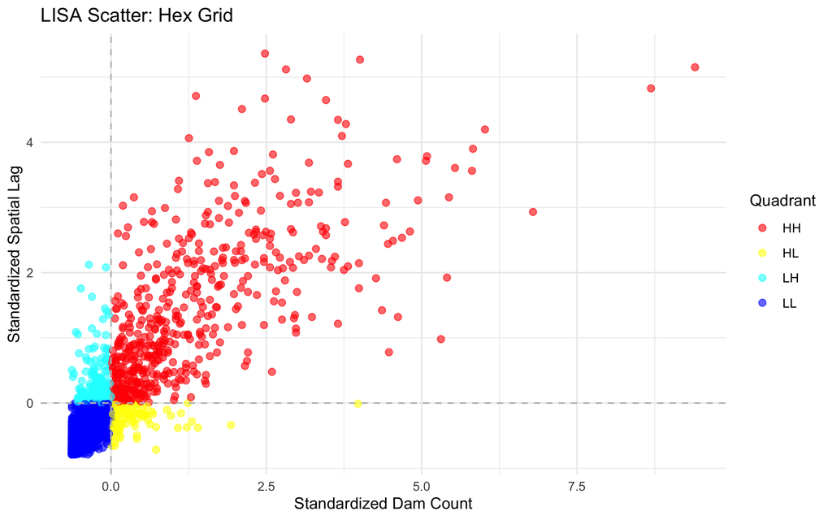

```r
lisa_hex <- assign_lisa_quadrants(lag_hex$imputed, lag_hex$lag)

hex_dams_lisa$z     <- lisa_hex$z_attr
hex_dams_lisa$lag_z <- lisa_hex$z_lag
hex_dams_lisa$lisa  <- lisa_hex$quadrant

# Part a Moran scatterplot
ggplot(hex_dams_lisa, aes(x = z, y = lag_z, color = lisa)) +
  geom_point(size = 2, alpha = 0.6) +
  geom_hline(yintercept = 0, linetype = "dashed", color = "gray") +
  geom_vline(xintercept = 0, linetype = "dashed", color = "gray") +
  scale_color_manual(values = c("HH" = "red", "LL" = "blue",
                                "HL" = "yellow", "LH" = "cyan"),
                     na.value = "gray80") +
  labs(title = "LISA Scatter: Hex Grid",
       x = "Standardized Dam Count",
       y = "Standardized Spatial Lag",
       color = "Quadrant") +
  theme_minimal()
```

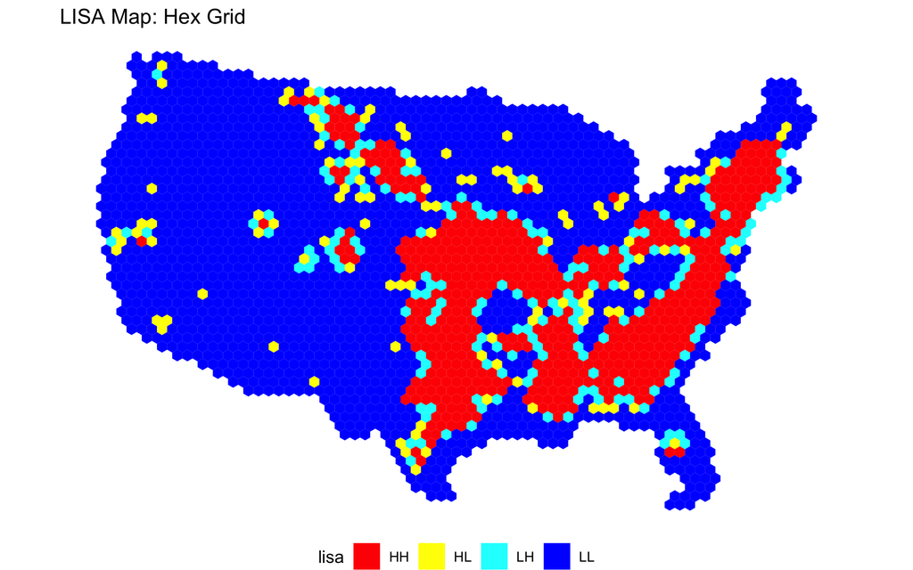

```r
# Part b LISA geographic map
p_hex_lisa <- plot_lisa_map(hex_dams_lisa, "LISA Map: Hex Grid")
p_hex_lisa
```

### Step 6.4

**Comparison with required county baseline**:

**a.** Repeat Steps 6.2–6.3 for counties.

**b. REQUIRED DELIVERABLE:** Create side-by-side LISA maps of **your chosen tessellation (from Q3)** and **counties** in the same figure. Use identical quadrant labels and color mapping in both panels so visual differences reflect unit choice, not styling.

**c.** **Quantitative comparison**: For both units, count the number of polygons in each quadrant. Example output: - Hexagon: HH=15 tiles, LL=23 tiles, HL=5 tiles, LH=2 tiles - Counties: HH=205 counties, LL=1300 counties, HL=240 counties, LH=360 counties - **Interpretation**: Are quadrant distributions similar (robust LISA pattern) or different (MAUP sensitive at local scale)?

**d.** Interpret: Which unit reveals clustering more clearly for your purpose? Do patterns align between your chosen tessellation and counties, or does MAUP (modifiable areal unit problem) create divergent local structure?

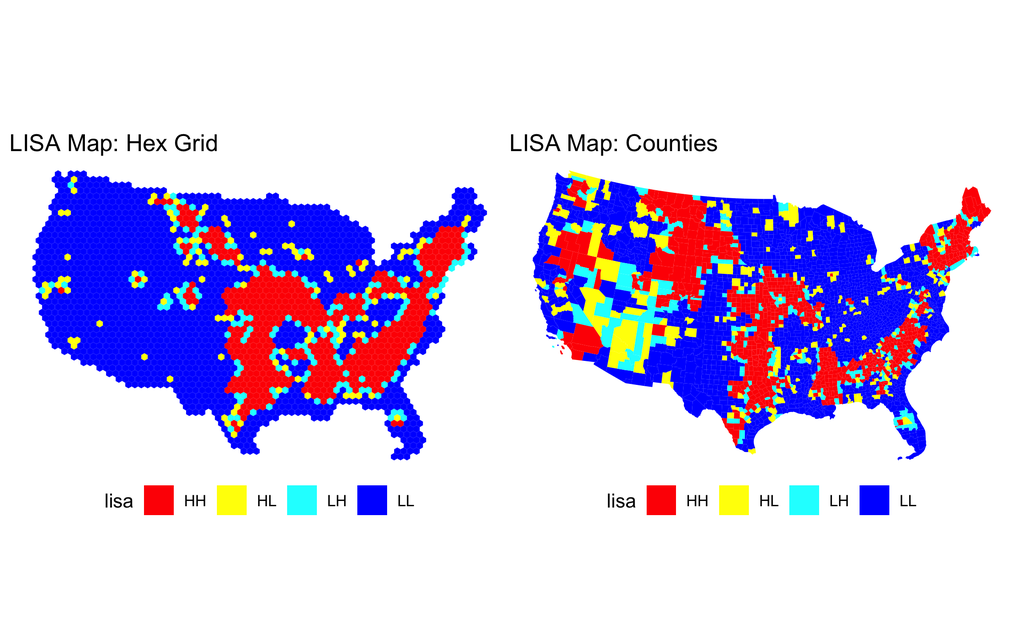

```r
lisa_county <- assign_lisa_quadrants(lag_county$imputed, lag_county$lag)

county_dams_lisa$z     <- lisa_county$z_attr
county_dams_lisa$lag_z <- lisa_county$z_lag
county_dams_lisa$lisa  <- lisa_county$quadrant

# LISA map for counties
p_county_lisa <- plot_lisa_map(county_dams_lisa, "LISA Map: Counties")

# Side by side comparison
library(patchwork)
p_hex_lisa + p_county_lisa
```

```r
# Hex quadrant counts
hex_dams_lisa %>%
  st_drop_geometry() %>%
  count(lisa)
```

```
  lisa    n
1   HH  525
2   HL  111
3   LH  171
4   LL 1501
```

```r
# County quadrant counts
county_dams_lisa %>%
  st_drop_geometry() %>%
  count(lisa)
```

```
  lisa    n
1   HH  756
2   HL  232
3   LH  317
4   LL 1803
```

### Step 6.5

**Geographic Interpretation and Management Implications**

Write a 3–4 paragraph synthesis addressing:

**a.** **Geographic hotspots and coldspots**: Identify major clustering regions: - Which dams are in HH hotspots? (E.g., TVA dams, Colorado River dams, others?) - Which regions are LL coldspots? (Mountains, deserts, sparse-development areas?) - What management or hydrologic factors explain these patterns?

**Specific region example:** Choose one HH hotspot (e.g., Tennessee Valley Authority region, Colorado River Basin, California Central Valley) and describe three factors that explain why TVA dams or Colorado River dams cluster. Use geographic knowledge or brief web research if needed.

**b.** **Outliers and anomalies**: Are there notable HL or LH tiles? What might explain them?

**c.** **Unit comparison**: Does analysis unit choice (hexagon vs. county) affect LISA conclusions? How does MAUP operate at the local scale?

**d.** **Implications for management**: How does LISA output inform dam operations, reporting, or policy? - Where should multi-state coordination efforts focus? (HH hotspots) - Which regions have simple management structures? (LL coldspots) - How do your LISA findings from Q6 compare to the dam purpose patterns you identified in Q4? (E.g., do irrigation dams cluster the same way as all dams?) - Where do policies need special attention to local anomalies? (HL/LH outliers)

The LISA analysis highlights several clear hotspot (HH) and coldspot (LL) regions across the United States. The strongest hotspots form a connected band running through the central Midwest and into the southeastern United States, roughly following the Mississippi and Missouri River systems and extending into the Appalachian region. Another smaller hotspot appears in the Northeast corridor. These regions contain many dams that are surrounded by neighboring areas with similarly high dam densities. One example is the Tennessee Valley Authority (TVA) region, where dams cluster due to several factors: the presence of large river networks suitable for dam construction, historic federal investment in water infrastructure during the 1930s–1950s, and the need for flood control, hydroelectric power, and navigation improvements. In contrast, much of the western United States appears as a large LL coldspot, meaning tiles with few dams are surrounded by other low-density tiles. This pattern likely reflects lower population density in many areas, harsher terrain in mountain and desert regions, and fewer suitable large river systems for dense dam infrastructure.

There are also several HL and LH outlier tiles that stand out from the surrounding pattern. HL tiles represent locations with relatively high dam counts surrounded by neighbors with fewer dams. These can occur near the edges of major dam clusters or in places where a specific watershed contains many dams but surrounding areas do not. For example, a tile might contain a major reservoir system or irrigation network while neighboring tiles cover mountainous or sparsely developed terrain. LH tiles represent the opposite situation—areas with relatively few dams surrounded by neighbors that contain more dams—which often occurs along the boundaries between hotspot and coldspot regions.

Comparing the hexagonal grid and county units shows how the choice of spatial unit influences the results. The hex grid produces a cleaner and more continuous pattern of hotspots and coldspots because every tile is the same size and shape. This makes regional clustering easier to interpret. In contrast, the county map appears more fragmented and noisy, especially in the western United States where counties are much larger than those in the east. Some counties appear as HL or LH outliers simply because their neighbors vary widely in area and dam density. This illustrates the Modifiable Areal Unit Problem (MAUP), where the patterns we observe depend on how spatial boundaries are defined. At the local scale, MAUP can create artificial anomalies that do not reflect real geographic differences.

From a management perspective, the LISA results highlight where coordinated water management efforts may be most important. HH hotspot regions, such as the Mississippi River basin and the southeastern United States, contain dense networks of dams that likely require coordinated planning across multiple states and agencies. In contrast, LL coldspot regions in the western United States may have simpler management structures because dams are more widely spaced and fewer neighboring systems interact. These results are also broadly consistent with patterns observed earlier in the assignment when mapping dam purposes, where irrigation and flood control dams showed regional clustering tied to climate and watershed conditions. Identifying hotspots and outliers through LISA analysis can help managers focus attention on regions where infrastructure is highly interconnected or where unusual local conditions may require more targeted policy or operational decisions.